# 3 Programming basics

[Book](http://rafalab.dfci.harvard.edu/dsbook/r-basics.html)

# Functions in this chapter

`any` `all` `else` `function` `if` `ifelse` `is.na` `map_dbl` `sapply` `search`

# 3.1 Conditional expressions

`if()`, `else`

```r
a <- 0

if (a != 0) {
  print(1/a)
} else {
  print("No reciprocal for 0")
}
```

```
## [1] "No reciprocal for 0"
```

Let’s look at one more example using the US murders data frame:

```r
library(dslabs)
data(murders)
murder_rate <- murders$total / murders$population * 10^5
```

Here is a very simple example that tells us which states, if any, have a murder rate lower than 0.5 per 100,000. The if statement protects us from the case in which no state satisfies the condition.

```r
ind <- which.min(murder_rate)

if (murder_rate[ind] < 0.5) {
  print(murders$state[ind])
} else {
  print("No state has a murder rate that low")
}
```

```
## [1] "Vermont"
```

```r
ind <- which.min(murder_rate)

if (murder_rate[ind] < 0.25) {
  print(murders$state[ind])
} else {
  print("No state has a murder rate that low")
}
```

```
## [1] "No state has a murder rate that low"
```

`ifelse()`

```r
a <- c(0, 1, 2, -4, 5)
result <- ifelse(a > 0, 1/a, NA)
result
```

```
## [1]  NA 1.0 0.5  NA 0.2
```

This table helps us see what happened:

| a | is_a_positive | answer1 | answer2 | result |
| --- | --- | --- | --- | --- |
| 0 | FALSE | Inf | NA | NA |
| 1 | TRUE | 1.00 | NA | 1.0 |
| 2 | TRUE | 0.50 | NA | 0.5 |
| -4 | FALSE | -0.25 | NA | NA |
| 5 | TRUE | 0.20 | NA | 0.2 |

Here is an example of how this function can be readily used to replace all the missing values in a vector with zeros: `is.na()`

```r
data("na_example")
no_nas <- ifelse(is.na(na_example), 0, na_example)
sum(is.na(no_nas))
```

```
## [1] 0
```

Two other functions are `any()` and `all()`. The `any` function takes a vector of logicals and returns `TRUE` if any of the entries are `TRUE`. The `all` function takes a vector of logicals and returns `TRUE` if all of the entries are `TRUE`. Here is an example:

```r
z <- c(TRUE, TRUE, FALSE)
any(z)
```

```
## [1] TRUE
```

```r
all(z)
```

```
## [1] FALSE
```

# 3.2 Defining functions

```r
avg <- function(x) {
  s <- sum(x)
  n <- length(x)
  s/n
}
```

```r
x <- 1:100
identical(mean(x), avg(x))
```

```
## [1] TRUE
```

Notice that variables defined inside a function are not saved in the workspace. So while we use `s` and `n` when we call `avg`, the values are created and changed only during the call.

The general form of a function definition looks like this:

```
my_function <- function(VARIABLE_NAME){
 perform operations on VARIABLE_NAME and calculate VALUE
 VALUE
}
```

Multiple arguments:

```r
avg <- function(x, arithmetic = TRUE) {
  n <- length(x)
  ifelse(arithmetic, sum(x)/n, prod(x)^(1/n))
}
```

# 3.3 Namespaces

```r
library(dplyr)
```

Use `search()` to see namespaces in search order

```r
search()
```

```
##  [1] ".GlobalEnv"        "package:dplyr"     "package:dslabs"
##  [4] "package:stats"     "package:graphics"  "package:grDevices"
##  [7] "package:utils"     "package:datasets"  "package:methods"
## [10] "Autoloads"         "package:base"
```

So what if we want to use the `stats` filter instead of the `dplyr` filter but `dplyr` appears first in the search list? You can force the use of a specific namespace by using double colons (::) like this:

```
stats::filter
```

# 3.4 For-loops

`for()`

```r
for (i in 1:5) {
  print(i)
}
```

```
## [1] 1
## [1] 2
## [1] 3
## [1] 4
## [1] 5
```

```r
compute_s_n <- function(n){
  x <- 1:n
  sum(x)
}
```

```r
m <- 25
s_n <- vector(length = m)
for (n in 1:m) {
  s_n[n] <- compute_s_n(n)
}
```

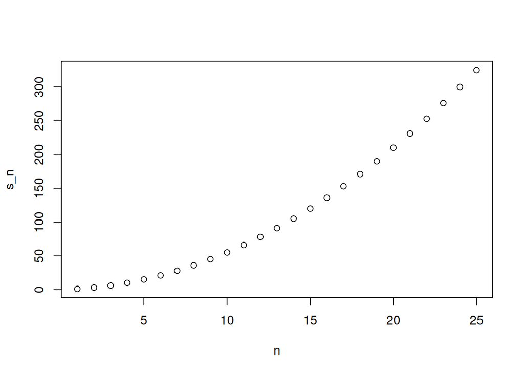

```r
n <- 1:m
plot(n, s_n)
```

# 3.5 Vectorization and functionals

```r
x <- 1:10
sqrt(x)
```

```
##  [1] 1.000000 1.414214 1.732051 2.000000 2.236068 2.449490 2.645751 2.828427
##  [9] 3.000000 3.162278
```

```r
y <- 1:10
x * y
```

```
##  [1]   1   4   9  16  25  36  49  64  81 100
```

To make this calculation, there is no need for for-loops. However, not all functions work this way. For instance, the function we just wrote, compute_s_n, does not work element-wise since it is expecting a scalar. This piece of code does not run the function on each entry of n:

```
n <- 1:25
compute_s_n(n)
```

**Functionals** are functions that help us apply the same function to each entry in a vector, matrix, data frame, or list. Here we cover the functional that operates on numeric, logical, and character vectors: `sapply()`.

```r
x <- 1:10
sapply(x, sqrt)
```

```
##  [1] 1.000000 1.414214 1.732051 2.000000 2.236068 2.449490 2.645751 2.828427
##  [9] 3.000000 3.162278
```

```r
n <- 1:25
s_n <- sapply(n, compute_s_n)
s_n
```

```
##  [1]   1   3   6  10  15  21  28  36  45  55  66  78  91 105 120 136 153 171 190
## [20] 210 231 253 276 300 325
```

Other functionals are `apply`, `lapply`, `tapply`, `mapply`, `vapply`, and `replicate`. We mostly use sapply, apply, and replicate in this book, but we recommend familiarizing yourselves with the others as they can be very useful.

# 3.6 Exercises

1. What will this conditional expression return?

```r
x <- c(1,2,-3,4)

if(all(x>0)){
  print("All Postives")
} else{
  print("Not all positives")
}
```

```
## [1] "Not all positives"
```

2. Which of the following expressions is always FALSE when at least one entry of a logical vector x is TRUE?
1. all(x)
2. any(x)
3. any(!x)
4. all(!x)

d

3. The function `nchar()` tells you how many characters long a character vector is. Write a line of code that assigns to the object new_names the state abbreviation when the state name is longer than 8 characters.

```r
ind <- which(nchar(murders) > 8)
new_names <- ifelse(nchar(murders$state) > 8, murders$abb, murders$state)
new_names
```

```
##  [1] "Alabama"  "Alaska"   "Arizona"  "Arkansas" "CA"       "Colorado"
##  [7] "CT"       "Delaware" "DC"       "Florida"  "Georgia"  "Hawaii"
## [13] "Idaho"    "Illinois" "Indiana"  "Iowa"     "Kansas"   "Kentucky"
## [19] "LA"       "Maine"    "Maryland" "MA"       "Michigan" "MN"
## [25] "MS"       "Missouri" "Montana"  "Nebraska" "Nevada"   "NH"
## [31] "NJ"       "NM"       "New York" "NC"       "ND"       "Ohio"
## [37] "Oklahoma" "Oregon"   "PA"       "RI"       "SC"       "SD"
## [43] "TN"       "Texas"    "Utah"     "Vermont"  "Virginia" "WA"
## [49] "WV"       "WI"       "Wyoming"
```

4. Create a function `sum_n` that for any given value, say $n$, computes the sum of the integers from 1 to n (inclusive). Use the function to determine the sum of integers from 1 to 5,000.

```r
sum_n <- function (n) {
  sum(1:n)
}
sum_n(5000)
```

```
## [1] 12502500
```

5. Create a function `altman_plot` that takes two arguments, x and y, and plots the difference against the sum.

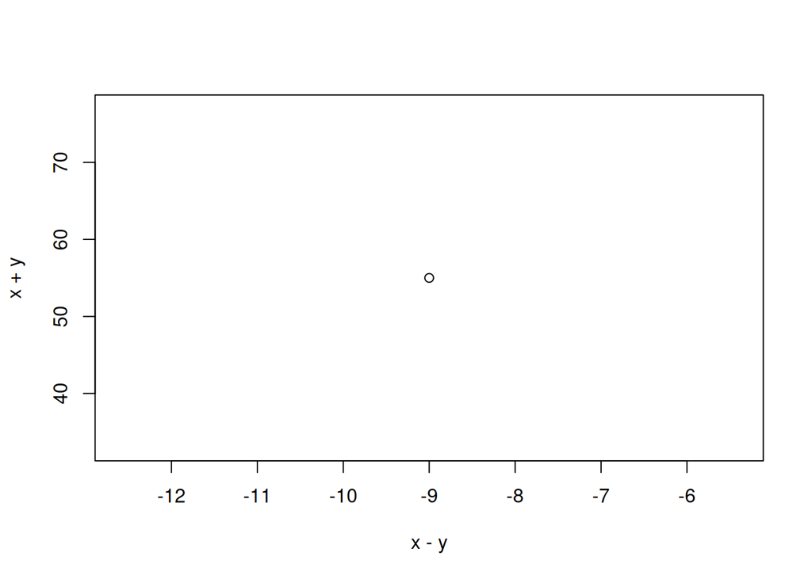

```r
altman_plot <- function(x, y) {
  plot(x-y, x+y)
}
altman_plot(23,32)
```

6. After running the code below, what is the value of x?

```
x <- 3
my_func <- function(y){
  x <- 5
  y+5
}
```

x = 3

7. Write a function `compute_s_n` that for any given $n$ computes the sum $S_n=1^2+2^2+3^2+\dots+n^2$. Report the value of the sum when $n=10$.

```r
compute_s_n <- function(n) {
  total <- 0
  for (x in 1:n) {
    total <- total + x^2
  }
  total
}
```

```r
compute_s_n(10)
```

```
## [1] 385
```

8. Define an empty numerical vector s_n of size 25 using s_n <- vector(“numeric”, 25) and store in the results of $S_1,S_2,\dots,S_25$ using a for-loop.

```r
s_n <- vector("numeric", 25)
compute_sq <- function(n) {
  n^2
}
```

```r
for (n in 1:25) {
  s_n[n] <- compute_sq(n)
}
s_n
```

```
##  [1]   1   4   9  16  25  36  49  64  81 100 121 144 169 196 225 256 289 324 361
## [20] 400 441 484 529 576 625
```

9. Repeat exercise 8, but this time use sapply.

```r
s_n <- sapply(1:25, compute_sq)
s_n
```

```
##  [1]   1   4   9  16  25  36  49  64  81 100 121 144 169 196 225 256 289 324 361
## [20] 400 441 484 529 576 625
```

10. Repeat exercise 8, but this time use `map_dbl`.

```r
# install.packages("purrr")
library("purrr")
```

```r
s_n <- map_dbl(1:25, compute_sq)
s_n
```

```
##  [1]   1   4   9  16  25  36  49  64  81 100 121 144 169 196 225 256 289 324 361
## [20] 400 441 484 529 576 625
```

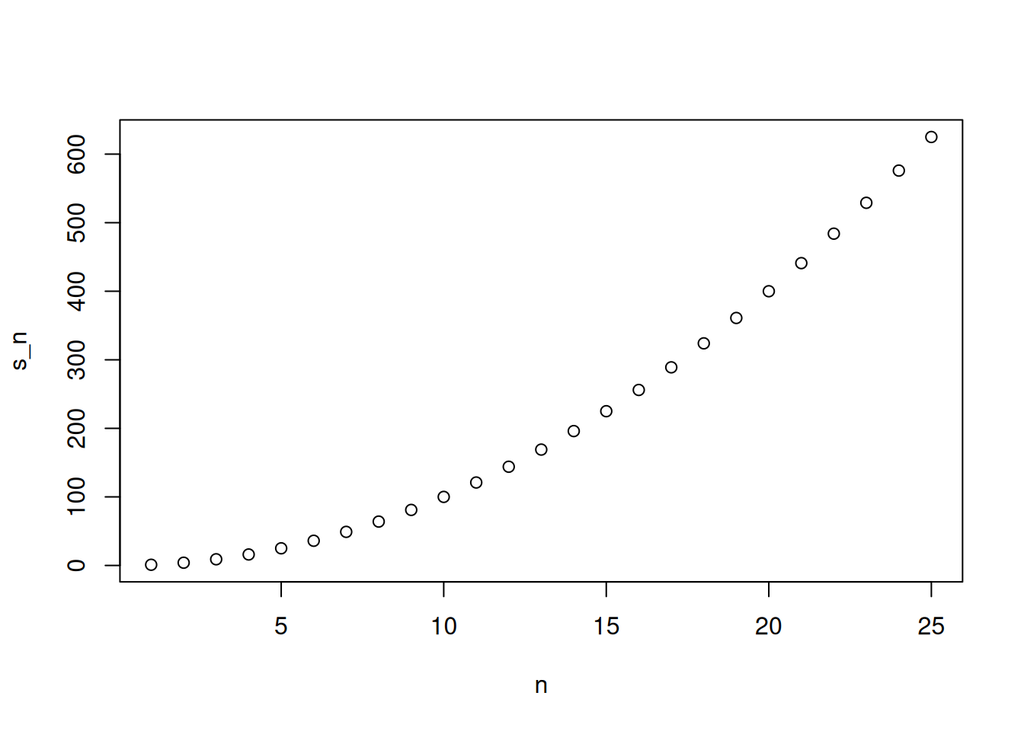

```r
n <- 1:25
plot(n, s_n)
```

12. Confirm that the formula for this sum is $S_n=n(n+1)(2n+1)/6$.

```r
compute_s_n(5)
```

```
## [1] 55
```

```r
new_sum <- function(n) {
  n*(n+1)*(2*n+1)/6
}
new_sum(5)
```

```
## [1] 55
```

```r
identical(compute_s_n(5), new_sum(5))
```

```
## [1] TRUE
```